# Stat 579 - Homework #4

9/18/2018

## Subsets and Visualizations: Movie Mojo

For this homework we are using the data set `mojo` from the classdata package. `mojo` constains data on box office revenue for movies based on the website https://www.boxofficemojo.com .

Run the following two commands to install the newest version of the package from github:

```r
library(devtools) # error? then run install.packages("devtools")
devtools::install_github("heike/classdata")
```

Check what is in the data set:

```r
library(classdata)
head(mojo)
```

```
##   TW LW                         Title Studio Weekend Gross % Change
## 1  1  1             Crazy Rich Asians     WB      21964345    -11.5
## 2  2  2                       The Meg     WB      10535459    -17.8
## 3  3  4 Mission: Impossible - Fallout   Par.       7032499    -13.0
## 4  4 22                     Searching   SGem       6066463   1460.4
## 5  5 NA              Operation Finale    MGM       6022758       NA
## 6  6  6    Disney's Christopher Robin     BV       5277955    -15.7
##   Theater Count Theater Change Average Total Gross Budget (in Million)
## 1          3865            339    5683   110691733                  30
## 2          3761           -270    2801   120521875                 130
## 3          2639           -413    2665   204379028                 178
## 4          1207           1198    5026     6574943                  NA
## 5          1818             NA    3313     7749853                  24
## 6          2925           -469    1804    85686823                  NA
##   Week                     Weekend Year WeekNo
## 1    3 August 31-September 2, 2018 2018     35
## 2    4 August 31-September 2, 2018 2018     35
## 3    6 August 31-September 2, 2018 2018     35
## 4    2 August 31-September 2, 2018 2018     35
## 5    1 August 31-September 2, 2018 2018     35
## 6    5 August 31-September 2, 2018 2018     35
```

##2. What is the difference between the variables `Week` and `WeekNo`? Describe in your words.

Week: the number of weeks the movie has been in theaters

Weekno: week number of the year

##3. Use `ggplot2` to plot total gross (`Total Gross`) against week number (`WeekNo`). Facet by Year. Interpret the result. Which movie had the highest total gross over the time frame? How many weeks was that movie on rank 1? How long was it in box offices overall?

```r
library(tidyverse)
```

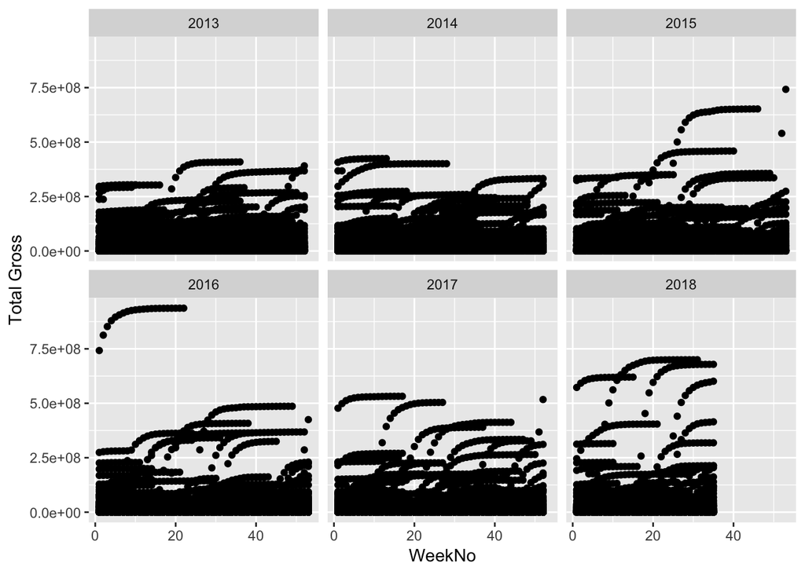

```r
data(mojo)

mojo %>%
  ggplot(aes(x = WeekNo, y = `Total Gross`)) +
  geom_point() + facet_wrap(~Year)
```

Most of the total gross of the moves are below 2.5e+8, fewer movies have relative high total gross. And the total gross increased fast at the beginning of being shown and became flat as the time went. These pictures look bad and need more clear investigation

```r
mojo[which.max(mojo$`Total Gross`), "Title"]
```

```
## [1] "Star Wars: The Force Awakens"
```

“Star Wars: The Force Awakens” has the highes total gross

```r
mojo %>%
  filter(Title == "Star Wars: The Force Awakens", TW == 1) %>%
  nrow()
```

```
## [1] 5
```

This movie has been on rank 1 for 5 weeks

```r
mojo %>%
  filter(Title == "Star Wars: The Force Awakens") %>%
  select(Week) %>%
  max()
```

```
## [1] 24
```

24 weeks, the movie was in box offices

##Q4. Pick two movies that were in box office some time between 2013 and 2018 and find the corresponding data in the `mojo` data. How does total gross of the two movies compare? Draw a plot and comment on the result.

I chose “Avengers: Age of Ultron” and “Avengers: Infinity War”

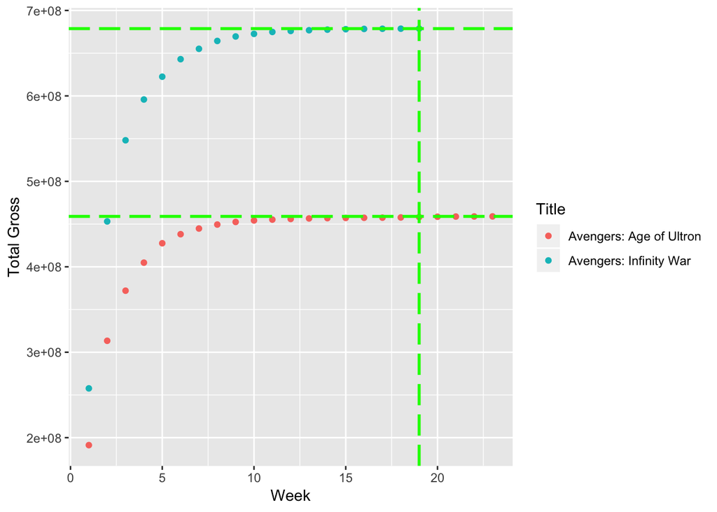

```r
mojo %>%
  filter(Title %in% c("Avengers: Age of Ultron",
                      "Avengers: Infinity War")) %>%
  ggplot(aes(x = Week, y = `Total Gross`, color = Title)) +
  geom_point() +
  geom_vline(xintercept = 19,
             colour = "green",
             linetype = "longdash",
             size = 1) +
  geom_hline(yintercept = c(678766226, 458991599),
             colour = "green",
             linetype = "longdash",
             size = 1)
```

The total gross of these two movies both increased very quick at the beginning, and the “Avengers: Infinity War” increased even a lot more faster. And at the end, “Avengers: Infinity War” achieved a total gross around $680 million, “Avengers: Age of Ultron”achieved a total gross around $459 million.

From the plot, we can see the increases are very fast for these two movies at the beginning. And the “Avengers: Infinity War” increased even faster. And the trends became flat after 10 weeks and arrived their final total gross.

##Q5. Hit or Flop? The variable `Budget (in Millions)` contains estimated budget numbers for some movies. For how many movies is this information available (careful! trick question - look at what the function `unique` does)? Studios would like to see their budget returned by the opening weekend. What is the percentage of movies for which that happened? How many movies did not have their budget matched in total gross by the third weekend? For each of these two questions describe your ‘plan of attack’, i.e. lay out how you go about finding an answer to the question. Identify one movie, that did not match its budget by week 3. Plot the incurred loss over time.

```r
mojo %>%
  filter(!is.na(`Budget (in Million)`)) %>%
  select(Title) %>%
  unique() %>%
  nrow()
```

```
## [1] 658
```

658 movies have budget information

```r
mojo %>%
  filter(!is.na(`Budget (in Million)`), Week == 1) %>%
  filter(`Total Gross` >= 1000000 * `Budget (in Million)`) %>%
  nrow()
```

```
## [1] 110
```

```r
110/658
```

```
## [1] 0.1671733
```

110 movies (16.7%) have their budget returned by the opening weekend

```r
mojo %>%
  filter(!is.na(`Budget (in Million)`), Week <= 3) %>%
  filter(`Total Gross` >= 1000000 * `Budget (in Million)`) %>%
  select(Title) %>%
  unique() %>%
  nrow()
```

```
## [1] 306
```

```r
658-306
```

```
## [1] 352
```

352 movies didn’t have made their budget matched in total gross by the third weekend

Before “Plan of attack”: first, there are some strange observations in the data set, which don’t have records in week 1, 2, or 3 but have record in later weeks’ records.(And even negative weeks) I avoid to discuss these obervations.

“Plan of attack”: I would first find out how many movies have Budget record. And get data in week 1 to see if they have their budgets returned in the first week. I would find those data have “week” variable less or equal to 3, in case that some movies are in theater less than 3 weeks. And find out how many of them matched their budgets in the first weeks. And use total number minus these movies, I got the final answer.

I chose “A Long Way Off” to draw the following plot.

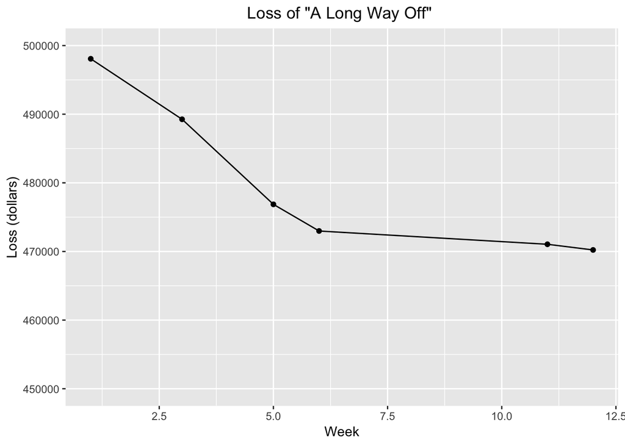

```r
mojo %>%
  filter(Title == "A Long Way Off") %>%
  mutate(loss = `Budget (in Million)`*1000000 - `Total Gross`) %>%
  ggplot(aes(x = Week, y = loss)) + geom_line() + geom_point() +
  ylim(450000, 500000) +
  labs(title = "Loss of \"A Long Way Off\" ", y = "Loss (dollars)") +
  theme(plot.title = element_text(hjust = 0.5))
```

Due date: the homework is due a week from now on Thursday.

For the submission: submit your solution in an R Markdown file and (just for insurance) submit the corresponding html/word file with it.